# Part II - FordGoBike Trip Analysis

## by Yusuff Adebayo

## Investigation Overview

> In this exploratory analysis, my project is based on exploring those features, of the FordGoBike trips dataset, that would be a good determinant of the trips duration as well as predicting whether a trip would be shared or not. The main features of focus are: age, duration, user_type, days of the week and member_gender.

## Dataset Overview

> The FordGoBike dataset contains 183,412 observations with 16 variables which include: Ride duration (Secs), Start and end time, Start and end station id and Name, Start and end station Latitutude and Longitude, Bike Id, User type, Member birth year, Member gender, Bike share for all trip (Yes or No). This variables contain information about individual rides in a bike-sharing system.

## Distribution of ride's duration and rider's age

Most of the riders prefer short term trip (from 0 minutes to 2 hours) and most of these riders are also youths i.e people between age 20 to 50 years. Also, those that ride more than 6, 15 hours are youth of age 38 or thereabout.

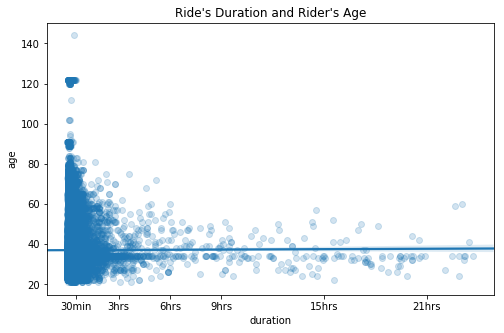

## Distribution of bike sharing and other important features such as user type and gender

91% of users do not share their bike, and there are more subscribers than customers just as there are more male users than their female counterparts. Only few other gender users exist.

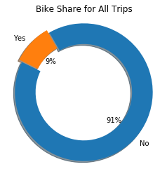

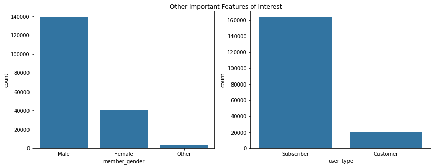

## Daily ride distribution

There are generally more trips during the weekdays than the weekends.

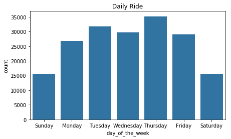

## Days of the week and their average trip duration

Interestingly, while there are more volumes of trips on weekdays, people actually spend more time on a ride during the weekends. Also, the median riding duration for eacn day of the week happens to be less than 10 minutes for both weekends and weekdays.

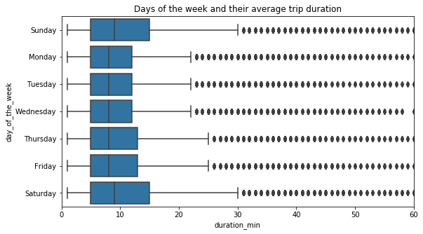

## The relationship between average daily trip duration and other important features (gender and user type)

Other gender happens to spend more time daily on trips followed by the female gender, while the male gender spend the least time on trips. Similarly, while the subscribers are spending around 10 minutes on average on their daily trip, customers are spending around 17 to 30 minutes daily.

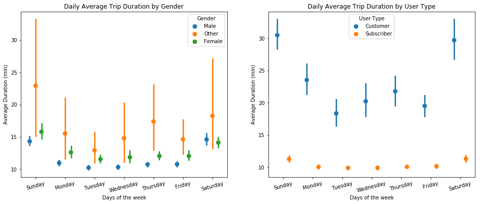